# 03_Get_resume_data.Rmd

Thorkil Klint

18/3/2018

# 1. Goals of this script

This markdown file describes how to draw data from the Danish parliament website into a tidy R data set. I will use mainly web scraping, but also the Danish Parliament API to achieve this goal. I progress in two steps:

1. I will scrape all html content from one side containing a parliamnent debate resumé, and use the stringr-package to make it into a usefull dataframe
2. I will derive a function, to scrape several resumé-URL’s, allowing me to perform task #1 on many pages quickly

I took the data-camp stringr-course, but that is all I know about regular expressions. If my code seem completely redundant, don’t hesitate to tell me!

## 1.1Bare neccessities

I start by loading all the packages I will need

```r
#Remove all objects
#rm(list = ls())

library(rvest) # To scrape web data
library(dplyr) #To manipulare data
library(stringr) #To work with strings in a concise way
library(httr) #To access anf get data from the twitter-api
library(rebus) #An intuitive guide to regular expressions
library(lubridate) #To work with dates and time date
library(ggplot2) #To plot!
```

# 2. Making one resumé-web-page into a dataframe.

The goal of this section is to make a parliament debate resumé web page into a data frame, where each row consist of a statement made on the floor, and each collumn describes different characteristics across these statements.

I start out by reading in the entire web page as an HTML-file

```r
debat1 <- read_html("http://www.ft.dk/forhandlinger/20161/20161M062_2017-02-23_1000.htm")
```

I had the choice to either 1) read in more specific content from the html-page or 2) read the entire page in, and then sort out the useful parts. Unfortunately, the html-format of the parliament page is not intuitive - the text I will have to use have both the class “Tekst” and “Tekstindryk”, depending on how it is portrayed on the site. Therefore, and as I find the text-formatting of the resumés pretty simple, I will mainly go with the latter way.

```r
#Make the downloadet html-content into a text file
text_debat1<-html_text(debat1) #Make the xml-object into a character string
class(debat1)
```

```
## [1] "xml_document" "xml_node"
```

```r
class(text_debat1)
```

```
## [1] "character"
```

```r
#result <- debat1 %>%
  #html_nodes(css = "p") #Gives all text elements, which does not help.
```

Next step is to find a pattern that allows me to seperate the text-file into different statements yielded on the floor. Luckily, each statements follows this pattern

*Parliament Member Name OR Parliament member title (Party OR Name): Statement Statement Banana*

An example could be,

*Lotte Rud (RV): Thank you. I …*

I exploid the fact, that the beginning of each statement is marked by a “):”. As I am not yet a regular-expression-champ, I use to rebus-package to get an intuitive sense, of what my patterns are searching for:

```r
#Set up a pattern
statement_pattern <- "\\)" %R% "\\:" #Means as ) followed by a :

#Pattern gives me 492 matches, and is equivalent of typing with regular expressions
str_count(text_debat1, statement_pattern)
```

```
## [1] 492
```

```r
str_count(text_debat1, "\\):")==str_count(text_debat1, statement_pattern)
```

```
## [1] TRUE
```

```r
#I split the text element everytime "\\):." occurs, and save it as a list
text_debat1_split1_list <- str_split(text_debat1, statement_pattern, n=Inf)

#I save the first element of the list (the actual text) as a character vector
debat1_matrix<-cbind(unlist(text_debat1_split1_list[[1]]))

#I now have a long list of statements.
debat1_matrix[2:4,]
```

```
## [1] "Mødet er åbnet.Det er i dag torsdag den 23. februar, og det betyder, at Folketingets formand fylder 70 år. Det får vi god anledning til andre steder at markere, så derfor overgår vi nu til vores almindelige vigtige arbejde og til Folketingets dagsorden i dag, torsdag den 23. februar 2017.Fra…
## [2] "Lovforslag nr. L 144 (Forslag til lov om ændring af lov om drift af landbrugsjorder. (Permanent genopdyrkningsret)) og Lovforslag nr. L 145 (Forslag til lov om ændring af lov om jordbrugets anvendelse af gødning og om plantedække. (Krav om etablering af målrettede efterafgrøder)).Søren Egge …
## [3] "Beslutningsforslag nr. B 71 (Forslag til folketingsbeslutning om indførelse af krav om helårsbeboelse i nyopførte boliger).Titler på de anmeldte sager vil fremgå af www.folketingstidende.dk (jf. ovenfor).Det første punkt på dagsordenen er:1) Spørgsmål om fremme af forespørgsel nr. F 42:Fores…
```

The split I made above - although effective - resultet in a minor, non-intuitive feature. The name of speaker, title of speaker, and time for each statement is located at the end of the forgoing statement. I will therefore have to extract these features. My first intution was to split every time “Kl.” occurs. “Kl.” is a danish abbreviation for “Klokken”, meaning O’Clock. This is because the resume gives the time just before each speaker takes the floor. Unfortunately, if a speaker has the floor a long time, the time is given inside the statement, yielding an ineffective split.

```r
pattern_time_split <- "Kl" %R% "\\." #Set up a pattern
naive_matrix<-str_split_fixed(debat1_matrix[,1], pattern=pattern_time_split, n=2) #Doing the naiive split
naive_matrix[261,2] #This should have been a time followed by a name, but is time followed by statement
```

```
## [1] " 13:53Min taletid er gået nu, og jeg vil læse et forslag til vedtagelse op, og det er på vegne af Enhedslisten, Socialdemokratiet, Radikale, Alternativet og SF:Forslag til vedtagelseFolketinget konstaterer, at 17 børneorganisationer har sendt et åbent brev til Folketingets partier med en anm…
```

I therefore split at the *last* time “Kl.” occurs in the string. As the stringr-package reads strings from left to right, I could not find any other way around this, than to reverse the entire string. Luckily, this was possible with the stringi-package (which the stringr-package is build on!)

```r
pattern_time_split_reverse <-  "\\." %R% "lK" #Set up a reversed pattern
# Ireverse the strings, and split at the first occurence of ".lK"
debat1_matrix_reverse <- stringr::str_split_fixed(stringi::stri_reverse(debat1_matrix[,1]), pattern=pattern_time_split_reverse, n=2) #n=2 secures that I only split the first time ".lK" occurs

debat1_matrix_reverse[,1] <- stringi::stri_reverse(debat1_matrix_reverse[,1]) #reverse back
debat1_matrix_reverse[,2] <- stringi::stri_reverse(debat1_matrix_reverse[,2])#reverse back
debat1_df<- as.data.frame(debat1_matrix_reverse) #Make it into a data frame
```

Now, I have a data-frame where the first variable contains plenty of speaker information, and the other variable contains the statement. Although the data frame looks nice, it is misleading - my first split separated the speaker from the statement, resultning in a dataset where the real speaker name occurs in the row *before* the statement. I therefore move speaker name down one row.

```r
debat1_df[2:nrow(debat1_df),1]<-debat1_df[1:nrow(debat1_df)-1,1]
```

Now I can start extracting all the information from the first variable, to put each type of information into a variable of its own.

### 2.1 Time of statement

I start by making a time variable. I set up a pattern, following the fact that time is marked with XX:XX

```r
#I make a time pattern
time_pattern <- DGT %R% DGT %R% ":" %R% DGT %R% DGT

#And then extract it
debat1_df$time <- stringr::str_extract(debat1_df[,1], pattern=time_pattern)
```

### 2.2 Is the speaker the chairman

```r
debat1_df$chairman <- str_detect(debat1_df$V1, "Formand|formand") #Codes yes if formand [danish for chair] occurs
```

### 2.3 Speaker name

```r
#Load the member data
setwd("/Users/thorkilklint/Documents/Berkeley/PS239T_Computational/thorkil-klint-ps239T-final-project/Data")
all_members_df<-readRDS("all_members_data.Rda")
str(all_members_df)
```

```
## 'data.frame':    292 obs. of  8 variables:
##  $ id            : chr  "5" "12" "13" "17" ...
##  $ name          : chr  "Frank Aaen" "Nicolai Wammen" "Sara Olsvig" "Christine Antorini" ...
##  $ typeid        : chr  "5" "5" "5" "5" ...
##  $ biografi      : chr  "<?xml version=\"1.0\" encoding=\"utf-16\"?>\n<membersMember xmlns:xsi=\"http://www.w3.org/2001/XMLSchema-instan"| __truncated__ "<membersMember tid=\"0\"><itemname>SNIWA</itemname><url>http://www.ft.dk/da/medlemmer/folketingetsmedlemmer/nic"| __truncated__ "<?xml version=…
##  $ party         : chr  "(EL)" "(S)" "(IA)" "(S)" ...
##  $ education     : chr  "Cand.oecon." "Cand.scient.pol." "Antropolog" "Stud.scient.pol." ...
##  $ academic      : logi  TRUE TRUE TRUE FALSE TRUE TRUE ...
##  $ education_fill: chr  "Academic Eduction" "Academic Eduction" "Academic Eduction" "No Academic Eduction" ...
```

Now, I can set up an rebus or-function, named after the vector with all member names. The function or1() is a quick way of seperating all the vectors elements in the name variable with a | in a regular expression.

```r
## Set up a pattern to detect member names in resume data
member_pattern <- rebus::or1(all_members_df$name)

#Make the variable with speaker name
debat1_df$name <- stringr::str_extract(debat1_df$V1, pattern=member_pattern)
```

### 2.4 Speaker party

Now that I know the name of each speaker, I can merge the debate-dataset with data from the api, to get the final data set for this debate!, containing both the four variables created from the resume data (statement, time, speaker_name and chairman) and the variables that was created in the Get_member_data.Rmd - script!

```r
#I make a shorter version of member data withoutunimportant variables
member_df_merge <- dplyr::select(all_members_df, -biografi, -typeid, -education)
#I merge the data
debat1_df<- dplyr::left_join(debat1_df, member_df_merge, by = "name")
```

Finally, I can give the data intuitive variable names and save it

```r
#I remove the first four lines, as these are meta-comments before the debate starts
debat1_df<- debat1_df[5:nrow(debat1_df),]

#I remove the variable V1, that was used to get the meta info
debat1_df<- dplyr::select(debat1_df, -V1)

#I rename the variable V2 to "statement"
names(debat1_df)[names(debat1_df) == "V2"] <- "statement"
#And then i make it into a character
class(debat1_df$statement)
```

```
## [1] "factor"
```

```r
debat1_df$statement <- as.character(debat1_df$statement)
class(debat1_df$statement)
```

```
## [1] "character"
```

```r
#And now, I save the data
#setwd("/Users/thorkilklint/Documents/Berkeley/PS239T_Computational/thorkil-klint-ps239T-final-project/Data")
#getwd()
#write.csv(debat1_df, "debate1_final_project.csv")
#str(debat1_df)
```

And to get a sense of the data, I can make a plot This plot shows, that since the minister is from LA and the chair is from EL, they make by far the most statements

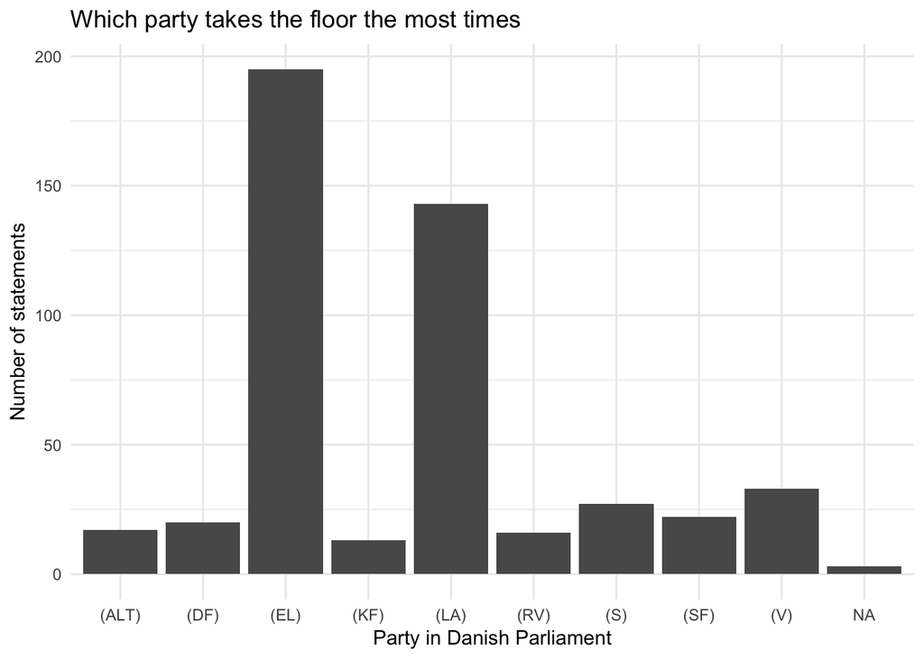

```r
ggplot(debat1_df, aes(x=party))+
  geom_bar()+
  theme_minimal()+
  labs(title="Which party takes the floor the most times")+
    ylab("Number of statements") +
    xlab("Party in Danish Parliament")
```

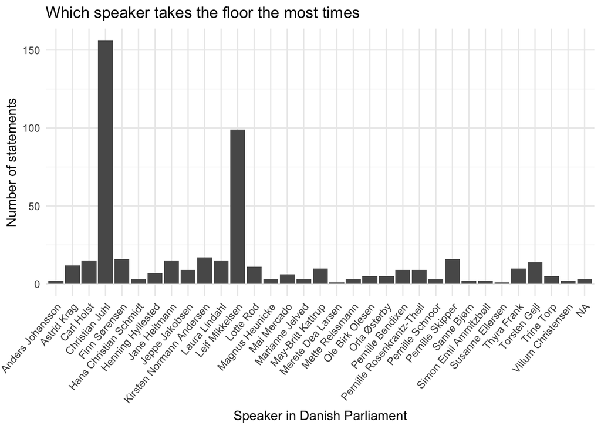

```r
ggplot(debat1_df, aes(x=name))+
  geom_bar()+
  theme_minimal()+
  theme(axis.text.x = element_text(angle = 50, hjust = 1))+
  labs(title="Which speaker takes the floor the most times")+
    ylab("Number of statements") +
    xlab("Speaker in Danish Parliament")
```

# 3. Scraping over several url’s

In this section I will apply the work from above in a loop that scrapes several debates at once

# 3.1 Get a vector of URL’s to scrape over

The first step in order to scrape more than one URL is to get a vector with several URL’s for different relevant parliament debates. This can be done by scraping all the URL’s from the following web-site that contains on overview of different parliament debate resumés

http://www.ft.dk/da/dokumenter/dokumentlister/referater?pageSize=200&startDate=20161201

Here, I have manually set start date and page size, to allow for as many debates as possible. For my final project, I will write a function that creates the URL for getting the debate-urls based on e.g. when the debates were held

I start by reading the entire overview page

```r
 #Read the entire page
overview <- read_html("http://www.ft.dk/da/dokumenter/dokumentlister/referater?pageSize=200&startDate=20161201")
```

### 3.1.1 Write a function that creates the overview-URL based on its content

To retype and update this URL by hand later will be a mess, so I make a quick function for updating the URL

```r
create_resume_url <- function(n=NULL, start=NULL, end=NULL){
  #This function takes three arguments,
    # n= number of resume urls pr page
    # start = start date, in the format YYYYMMDD
    # end = end date, in the format YYYYMMDD

  #If n is specified, set up a variable called page size, consisting of relevant url-code
  if (length(n)>0){
    n <- paste0("pageSize=",n, "&")
  }

  #If start is specified, set up a variable called start date, consisting of relevant url-code
  if (length(start)>0){
    start <- paste0("startDate=",start, "&")
  }

  #If end is specified, set up a variable called end date, consisting of relevant url-code
  if (length(end)>0){
    end <- paste0("endDate=",end, "&")
  }

  #Paste all the variable together
  url <- paste0("http://www.ft.dk/da/dokumenter/dokumentlister/referater?", n, start, end)

  #The url may not end with a "&" - i therefore delete the last letter if it does, and print the URL
  if (stringr::str_sub(url, start=-1L)=="&"){
    url <- stringr::str_sub(url, start=1L, end=-2L)
    print(url)
  } else {
    print(url)
  }
}
```

### 3.1.2 Scrape the URL’s from the overview-page

In order to scrape all the URL’s from the webpage, I check out the HTML-structure, and decide what objects to draw. The selecter tool helps me to realize, that I need the objects with class=highlighted, type = a to get all the urls and the date for each debate

```r
#Make a result list from the css-code
results <- overview %>%
  html_nodes(css = ".highlighted a")
```

Now, I can take this list, and make it into a dataframe with all the URL’s

```r
#I then remove the first element of the list, as this is meta-data
results <- results[-1]

# I create empty placeholder for the urls
debates <- vector("list", length = length(results))

# I set up a function to save document names and urls
for (i in 1:length(results)) { #for every element in the list results
    date <- lubridate::dmy_hm(str_sub(html_text(results[i]),27,42))
    #Take from 27th till 42nd element of str, which is the date, and make a data-character variable. Then make it into POSIXct format
    url <- html_attr(results[i], "href") #takes the url (using the href)
    debates[[i]] <- data_frame(date = date, url = url) # convert the two variables into a df, and store them in a list
    df_debates <- bind_rows(debates) #Convert the list into a data frame
}

# Finally, I can create full host webpage urls in the dataset
df_debates$url <- paste0("http://ft.dk", df_debates$url, sep="")
```

And now, I have a beutiful data frame with all the scraped URL’s

```r
str(df_debates)
```

```
## Classes 'tbl_df', 'tbl' and 'data.frame':    173 obs. of  2 variables:
##  $ date: POSIXct, format: "2018-04-20 10:00:00" "2018-04-19 10:00:00" ...
##  $ url : chr  "http://ft.dk/forhandlinger/20171/20171M086_2018-04-20_1000.htm" "http://ft.dk/forhandlinger/20171/20171M085_2018-04-19_1000.htm" "http://ft.dk/forhandlinger/20171/20171M084_2018-04-18_1300.htm" "http://ft.dk/forhandlinger/20171/20171M083_2018-04-17_1300.htm" ...
```

I save the data, as the format of the website might change in a not so distant future

```r
#And now, I save the data
getwd()
```

```
## [1] "/Users/thorkilklint/Documents/Berkeley/PS239T_Computational/thorkil-klint-ps239T-final-project/Code"
```

```r
setwd("/Users/thorkilklint/Documents/Berkeley/PS239T_Computational/thorkil-klint-ps239T-final-project/Data")
write.csv(df_debates, "url_resume_df.csv")
saveRDS(df_debates,file="url_resume_df.Rda")
```

## 3.2 Scraping all the html-files

Now, I will perform the first exercise (making a data frame of statements) across many debates.

```r
#Load data
setwd("/Users/thorkilklint/Documents/Berkeley/PS239T_Computational/thorkil-klint-ps239T-final-project/Data")
df_debates<-readRDS(file="url_resume_df.Rda")
```

### 3.2.1 The relevant URL’s

With help from the agenda-dataset, I can limit the debate-urls to the relevant debates (where the minister of immigration occurs more than 2 times on the agenda)

```r
#Load the agenda data
setwd("/Users/thorkilklint/Documents/Berkeley/PS239T_Computational/thorkil-klint-ps239T-final-project/Data")
url_agenda_data<-readRDS("url_agenda_df.Rda")

#Make a df with only the urls for the agendas of the relevant debates
relevant_agenda_data<-url_agenda_data[url_agenda_data$mentions>2,]

#I rename the variable url to agenda-url
names(relevant_agenda_data)[names(relevant_agenda_data) == "url"] <- "agenda_url"

#Load the debate data
setwd("/Users/thorkilklint/Documents/Berkeley/PS239T_Computational/thorkil-klint-ps239T-final-project/Data")
df_resumes_merge<-readRDS("url_resume_df.Rda")

#I rename the variable url to resume-url
names(df_resumes_merge)[names(df_resumes_merge) == "url"] <- "resume_url"

#And limit the time from the date, so the format is the same as url_agenda data
df_resumes_merge$date<-as.Date(df_resumes_merge$date, format="d%m%y%")

##Merge
relevant_debates_df<- dplyr::left_join(relevant_agenda_data, df_resumes_merge, by = "date")

#Save the data
setwd("/Users/thorkilklint/Documents/Berkeley/PS239T_Computational/thorkil-klint-ps239T-final-project/Data")
saveRDS(relevant_debates_df,file="resume_urls_to_loop_over.Rda")
write.csv(relevant_debates_df, "resume_urls_to_loop_over.csv")
```

### 3.2.2 Running the forloop

And then, I run the forloop (Now, with a try catch)

```r
#Load the data
setwd("/Users/thorkilklint/Documents/Berkeley/PS239T_Computational/thorkil-klint-ps239T-final-project/Data")
relevant_debates_df<-readRDS("resume_urls_to_loop_over.Rda")

#Make a list the length of the objects
resumes <- vector("list", length = nrow(relevant_debates_df))

#Set up patterns
time_pattern <- DGT %R% DGT %R% ":" %R% DGT %R% DGT #Time is always in pattern such as 13:05
statement_pattern <- "\\)" %R% "\\:" #Means as ) followed by a :
time_split_reverse_pattern <-  "\\." %R% "lK" #Set up a reversed pattern
start_with_time_pattern <- START %R% SPACE %R% DGT %R% DGT %R% ":" %R% DGT %R% DGT
member_pattern <- rebus::or1(all_members_df$name) #Take the member data, and make the member-or pattern

#And run the forloop with try catch
for (i in 1:nrow(relevant_debates_df)){
  resumes[[i]] <- tryCatch(expr={html_text(read_html(relevant_debates_df$resume_url[i]))},
                             error=function(e){return("No dataframe due to error")}) #Read in the files as text

  if(resumes[[i]]=="No dataframe due to error"){
    print(paste0("An error occured in url number ",i))
  }else{

  #Perform the first split split
  first_split_count <- str_count(resumes[[i]], statement_pattern) #Print if it worked
  print(paste0("Statement pattern occured ", first_split_count, " times in debate", i))
  resumes[[i]] <- str_split(resumes[[i]], statement_pattern, n=Inf)
  resumes[[i]]<-cbind(unlist(resumes[[i]][[1]]))

  #Second split, #n=2 secures split only the first time ".lK" occurs
  resumes[[i]] <- stringr::str_split_fixed(stringi::stri_reverse(resumes[[i]][,1]),
                                           pattern=time_split_reverse_pattern, n=2)
  resumes[[i]][,1] <- stringi::stri_reverse(resumes[[i]][,1]) #reverse back
  resumes[[i]][,2] <- stringi::stri_reverse(resumes[[i]][,2])#reverse back
  resumes[[i]]<- as.data.frame(resumes[[i]]) #Make it into a data frame

  #Remove the meta rows in df (does not start with a time)
  resumes[[i]]<-resumes[[i]][str_detect(resumes[[i]][,1], start_with_time_pattern),]

  #Extract the time and create a variable
  resumes[[i]]$time <- stringr::str_extract(resumes[[i]][,1], pattern=time_pattern)

  #Make the variable with speaker name
  resumes[[i]]$name <- stringr::str_extract(resumes[[i]]$V1, pattern=member_pattern)
  #Move speaker one down, as the split seperated them
  resumes[[i]]$name[2:nrow(resumes[[i]])]<-resumes[[i]]$name[1:nrow(resumes[[i]])-1]

  Sys.sleep(5) #So I dont take down the government
  }
}

str(resumes[[1]])
```

Save the data

```r
#Save the respective data sets
setwd("/Users/thorkilklint/Documents/Berkeley/PS239T_Computational/thorkil-klint-ps239T-final-project/Data")
getwd()
for (i in 1:length(resumes)){
  saveRDS(resumes[[i]],file=paste0("resume_debate_",i,".Rda"))
}

for (i in 1:length(resumes)){
  write.csv(resumes[[i]],file=paste0("resume_debate_",i,".csv"))
}
```